# 🌈 데이콘 101

따릉이 데이터를 활용한 데이터 분석

https://dacon.io/competitions/open/235698/overview/description

## Lv.2 결측치 보간법과 랜덤포레스트로 따릉이 데이터 예측하기

```python
# 데이터 다운로드 링크로 데이터를 코랩에 불러옵니다.

!wget 'https://bit.ly/3gLj0Q6'

import zipfile
with zipfile.ZipFile('3gLj0Q6', 'r') as existing_zip:
    existing_zip.extractall('data')
```

[output not shown]

## **1. 라이브러리 및 데이터 Library & Data**

```python
import pandas as pd

train = pd.read_csv('/content/data/train.csv')
test = pd.read_csv('/content/data/test.csv')
```

## **2. EDA**

```python
# train 데이터

train.info()
train.isna().sum()
```

```
<class 'pandas.core.frame.DataFrame'>
RangeIndex: 1459 entries, 0 to 1458
Data columns (total 11 columns):
 #   Column                  Non-Null Count  Dtype
---  ------                  --------------  -----
 0   id                      1459 non-null   int64
 1   hour                    1459 non-null   int64
 2   hour_bef_temperature    1457 non-null   float64
 3   hour_bef_precipitation  1457 non-null   float64
 4   hour_bef_windspeed      1450 non-null   float64
 5   hour_bef_humidity       1457 non-null   float64
 6   hour_bef_visibility     1457 non-null   float64
 7   hour_bef_ozone          1383 non-null   float64
 8   hour_bef_pm10           1369 non-null   float64
 9   hour_bef_pm2.5          1342 non-null   float64
 10  count                   1459 non-null   float64
dtypes: float64(9), int64(2)
memory usage: 125.5 KB
```

```
id                          0
hour                        0
hour_bef_temperature        2
hour_bef_precipitation      2
hour_bef_windspeed          9
hour_bef_humidity           2
hour_bef_visibility         2
hour_bef_ozone             76
hour_bef_pm10              90
hour_bef_pm2.5            117
count                       0
dtype: int64
```

```python
# test 데이터

test.info()
test.isna().sum()
```

```
<class 'pandas.core.frame.DataFrame'>
RangeIndex: 715 entries, 0 to 714
Data columns (total 10 columns):
 #   Column                  Non-Null Count  Dtype
---  ------                  --------------  -----
 0   id                      715 non-null    int64
 1   hour                    715 non-null    int64
 2   hour_bef_temperature    714 non-null    float64
 3   hour_bef_precipitation  714 non-null    float64
 4   hour_bef_windspeed      714 non-null    float64
 5   hour_bef_humidity       714 non-null    float64
 6   hour_bef_visibility     714 non-null    float64
 7   hour_bef_ozone          680 non-null    float64
 8   hour_bef_pm10           678 non-null    float64
 9   hour_bef_pm2.5          679 non-null    float64
dtypes: float64(8), int64(2)
memory usage: 56.0 KB
```

```
id                         0
hour                       0
hour_bef_temperature       1
hour_bef_precipitation     1
hour_bef_windspeed         1
hour_bef_humidity          1
hour_bef_visibility        1
hour_bef_ozone            35
hour_bef_pm10             37
hour_bef_pm2.5            36
dtype: int64
```

## **3. 결측치**

### 1). 평균값으로 대체

**df.fillna({'칼럼명':int(df['칼럼명'].mean)}, inplace=True)**

```python
train.fillna({'hour_bef_temperature':int(train['hour_bef_temperature'].mean())}, inplace=True)
train.fillna({'hour_bef_precipitation':int(train['hour_bef_precipitation'].mean())}, inplace=True)
train.fillna({'hour_bef_windspeed':int(train['hour_bef_windspeed'].mean())}, inplace=True)
train.fillna({'hour_bef_humidity':int(train['hour_bef_humidity'].mean())}, inplace=True)
train.fillna({'hour_bef_visibility':int(train['hour_bef_visibility'].mean())}, inplace=True)
train.fillna({'hour_bef_ozone':int(train['hour_bef_ozone'].mean())}, inplace=True)
train.fillna({'hour_bef_pm10':int(train['hour_bef_pm10'].mean())}, inplace=True)
train.fillna({'hour_bef_pm2.5':int(train['hour_bef_pm2.5'].mean())}, inplace=True)
```

```python
train.isna().sum()
```

```
id                        0
hour                      0
hour_bef_temperature      0
hour_bef_precipitation    0
hour_bef_windspeed        0
hour_bef_humidity         0
hour_bef_visibility       0
hour_bef_ozone            0
hour_bef_pm10             0
hour_bef_pm2.5            0
count                     0
dtype: int64
```

### 2). 보간법으로 대체

- Lv2 에서 다루고 있는 따릉이 데이터의 경우 피쳐들은 기상정보들이며 데이터의 순서는 시간 순서
- 결측치들을 이전 행(직전시간)과 다음 행(직후시간)의 평균으로 보간하는 것은 상당히 합리적
- interpolate() 를 이용해 결측치를 DataFrame 값에 선형으로 비례하여 보간

**df.interpolate(inplace=True)**

```python
train.interpolate(inplace=True)
```

```python
train.isna().sum()
```

```
id                        0
hour                      0
hour_bef_temperature      0
hour_bef_precipitation    0
hour_bef_windspeed        0
hour_bef_humidity         0
hour_bef_visibility       0
hour_bef_ozone            0
hour_bef_pm10             0
hour_bef_pm2.5            0
count                     0
dtype: int64
```

```python
test.interpolate(inplace=True)
test.isna().sum()
```

```
id                        0
hour                      0
hour_bef_temperature      0
hour_bef_precipitation    0
hour_bef_windspeed        0
hour_bef_humidity         0
hour_bef_visibility       0
hour_bef_ozone            0
hour_bef_pm10             0
hour_bef_pm2.5            0
dtype: int64
```

## **4. 모델링 : 랜덤포레스트**

- 랜덤포레스트는 여러 개의 의사결정나무를 만들어서 이들의 평균으로 예측의 성능을 높이는 방법
- 이러한 기법을 앙상블(Ensemble) 기법
- 주어진 하나의 데이터로부터 여러 개의 랜덤 데이터셋을 추출해, 각 데이터셋을 통해 모델을 여러 개 만들 수 있다

from sklearn.ensemble import RandomForestRegressor  
model = RandomForestRegressor()

```python
from sklearn.ensemble import RandomForestRegressor
model = RandomForestRegressor()
```

```python
train.drop(['count'], axis=1)
X_train = train.drop(['count'], axis=1)
X_train
```

|  | id | hour | hour_bef_temperature | hour_bef_precipitation | hour_bef_windspeed | hour_bef_humidity | hour_bef_visibility | hour_bef_ozone | hour_bef_pm10 | hour_bef_pm2.5 |
| --- | --- | --- | --- | --- | --- | --- | --- | --- | --- | --- |
| 0 | 3 | 20 | 16.3 | 1.0 | 1.5 | 89.0 | 576.0 | 0.027 | 76.0 | 33.0 |
| 1 | 6 | 13 | 20.1 | 0.0 | 1.4 | 48.0 | 916.0 | 0.042 | 73.0 | 40.0 |
| 2 | 7 | 6 | 13.9 | 0.0 | 0.7 | 79.0 | 1382.0 | 0.033 | 32.0 | 19.0 |
| 3 | 8 | 23 | 8.1 | 0.0 | 2.7 | 54.0 | 946.0 | 0.040 | 75.0 | 64.0 |
| 4 | 9 | 18 | 29.5 | 0.0 | 4.8 | 7.0 | 2000.0 | 0.057 | 27.0 | 11.0 |
| ... | ... | ... | ... | ... | ... | ... | ... | ... | ... | ... |
| 1454 | 2174 | 4 | 16.8 | 0.0 | 1.6 | 53.0 | 2000.0 | 0.031 | 37.0 | 27.0 |
| 1455 | 2175 | 3 | 10.8 | 0.0 | 3.8 | 45.0 | 2000.0 | 0.039 | 34.0 | 19.0 |
| 1456 | 2176 | 5 | 18.3 | 0.0 | 1.9 | 54.0 | 2000.0 | 0.009 | 30.0 | 21.0 |
| 1457 | 2178 | 21 | 20.7 | 0.0 | 3.7 | 37.0 | 1395.0 | 0.082 | 71.0 | 36.0 |
| 1458 | 2179 | 17 | 21.1 | 0.0 | 3.1 | 47.0 | 1973.0 | 0.046 | 38.0 | 17.0 |

1459 rows × 10 columns

```python
train['count']
y_train = train['count']
y_train
```

```
0        49.0
1       159.0
2        26.0
3        57.0
4       431.0
        ...
1454     21.0
1455     20.0
1456     22.0
1457    216.0
1458    170.0
Name: count, Length: 1459, dtype: float64
```

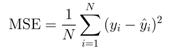

```python
RandomForestRegressor(criterion='mse')
# model = RandomForestRegressor(criterion = 'mse') Error: The 'criterion' parameter of RandomForestRegressor must be a str among {'absolute_error', 'squared_error', 'poisson', 'friedman_mse'}. Got 'mse' instead.

model = RandomForestRegressor()
model.fit(X_train, y_train)
```

```
RandomForestRegressor()
```

```python
model.predict(test)
pred = model.predict(test)
pred[:3]
```

```
array([ 95.47, 229.61,  86.37])
```

## **5. 튜닝**

- fit() 으로 모델이 학습되고 나면 **feature*importances*** 속성(attribute) 으로 변수의 중요도를 파악할 수 있음
- 변수의 중요도란? 예측변수를 결정할 때 각 피쳐가 얼마나 중요한 역할을 하는지에 대한 척도
- 변수의 중요도가 낮다면 해당 피쳐를 제거하는 것이 모델의 성능을 높일 수 있음

**model.feature*importances***

```python
model.feature_importances_
```

```
array([0.02597703, 0.59171476, 0.17804073, 0.01900395, 0.02520788,
       0.03359205, 0.03430154, 0.03984712, 0.03115666, 0.0211583 ])
```

```python
# X_train 에서 drop 할 피쳐의 경우에 수 대로 3개의 X_train 을 생성하세요.
# 각 train 에 따라 동일하게 피쳐를 drop 한 test 셋들을 생성하세요.

# train
X_train_1 = train.drop(['count','id'], axis=1)
X_train_2 = train.drop(['count','id','hour_bef_windspeed'], axis=1)
X_train_3 = train.drop(['count','id','hour_bef_windspeed','hour_bef_pm2.5'], axis=1)
# test
X_test_1 = test.drop(['id'],axis=1)
X_test_2 = test.drop(['id','hour_bef_windspeed'], axis=1)
X_test_3 = test.drop(['id','hour_bef_windspeed','hour_bef_pm2.5'], axis=1)
```

```python
# 각 X_train에 대해 모델 훈련을 해주세요.
model_1 = RandomForestRegressor()
model_1.fit(X_train_1,y_train)

model_2 = RandomForestRegressor()
model_2.fit(X_train_2,y_train)

model_3 = RandomForestRegressor()
model_3.fit(X_train_3,y_train)
```

```
RandomForestRegressor()
```

```python
# 각 모델로 test 셋들을 예측해주세요.
model_1.predict(X_test_1)
pred_1 = model_1.predict(X_test_1)

model_2.predict(X_test_2)
pred_2 = model_2.predict(X_test_2)

model_3.predict(X_test_3)
pred_3 = model_3.predict(X_test_3)
```

```python
print(f'예측1',pred_1[:3], '예측2',pred_2[:3], '예측3',pred_3[:3])
```

```
예측1 [ 87.17 222.8   77.75] 예측2 [ 91.11 213.53  80.36] 예측3 [ 92.91 212.89  80.17]
```

```python
#답안지 파일
submission1 = pd.read_csv('/content/data/submission.csv')
submission2 = pd.read_csv('/content/data/submission.csv')
submission3 = pd.read_csv('/content/data/submission.csv')

submission1['count'] = pred_1
submission2['count'] = pred_2
submission3['count'] = pred_3
```

```python
# 각 결과들을 submission 파일로 저장해주세요.
submission1.to_csv('sub_1.csv',index=False)
submission2.to_csv('sub_2.csv',index=False)
submission3.to_csv('sub_3.csv',index=False)
```